# Paid Maternity Leave

Jilung Hsieh

2018/7/2

# 1 案例：產假支薪

- 本案例將利用R來重製華盛頓郵報在2016/08/13的一篇談論美國婦女產假支薪情形的報導。這個案例中將會應用到data.frame和基本的繪圖與資料摘要方法。The case adaped Washington Post’s paid maternity leave as an exmaple to introduce basic skill of data.frame, plotting, and data mamipulation.
- 原始新聞來源：https://www.washingtonpost.com/news/worldviews/wp/2016/08/13/the-world-is-getting-better-at-paid-maternity-leave-the-u-s-is-not/?tid=sm_tw&utm_term=.f8cd50280326#comments

# 2 用readxl套件讀Excel檔

- readxl也包含在tidyverse的套件集中，所以應該已經在前次安裝過，不用特別安裝。

```r
library(readxl)
options(stringsAsFactors = FALSE)
```

# 3 乾淨的完整版程式

```r
ldata <- read_excel("data/WORLD-MACHE_Gender_6.8.15.xls", "Sheet1", col_names=T)

# select columns by index
matleave <- ldata[ , c(3, 6:24)]
str(matleave)
```

```
## Classes 'tbl_df', 'tbl' and 'data.frame':    197 obs. of  20 variables:
##  $ iso3       : chr  "AFG" "ALB" "DZA" "AND" ...
##  $ matleave_95: num  2 5 3 2 2 2 2 3 1 5 ...
##  $ matleave_96: num  2 5 3 2 2 2 2 3 1 5 ...
##  $ matleave_97: num  2 5 3 2 2 2 2 3 1 5 ...
##  $ matleave_98: num  2 5 3 2 2 2 2 3 1 5 ...
##  $ matleave_99: num  2 5 3 2 2 2 2 3 1 5 ...
##  $ matleave_00: num  2 5 3 3 2 2 2 3 1 5 ...
##  $ matleave_01: num  2 5 3 3 2 2 2 3 1 5 ...
##  $ matleave_02: num  2 5 3 3 2 2 2 3 1 5 ...
##  $ matleave_03: num  2 5 3 3 2 2 2 3 1 5 ...
##  $ matleave_04: num  2 5 3 3 2 2 2 5 1 5 ...
##  $ matleave_05: num  2 5 3 3 2 2 2 5 1 5 ...
##  $ matleave_06: num  2 5 3 3 2 2 2 5 1 5 ...
##  $ matleave_07: num  2 5 3 3 2 2 2 5 1 5 ...
##  $ matleave_08: num  2 5 3 3 2 2 2 5 1 5 ...
##  $ matleave_09: num  2 5 3 3 2 2 2 5 1 5 ...
##  $ matleave_10: num  2 5 3 3 2 2 2 5 NA 5 ...
##  $ matleave_11: num  2 5 3 3 2 2 2 5 3 5 ...
##  $ matleave_12: num  2 5 3 3 2 2 2 5 3 5 ...
##  $ matleave_13: num  2 5 3 3 2 2 2 5 3 5 ...
```

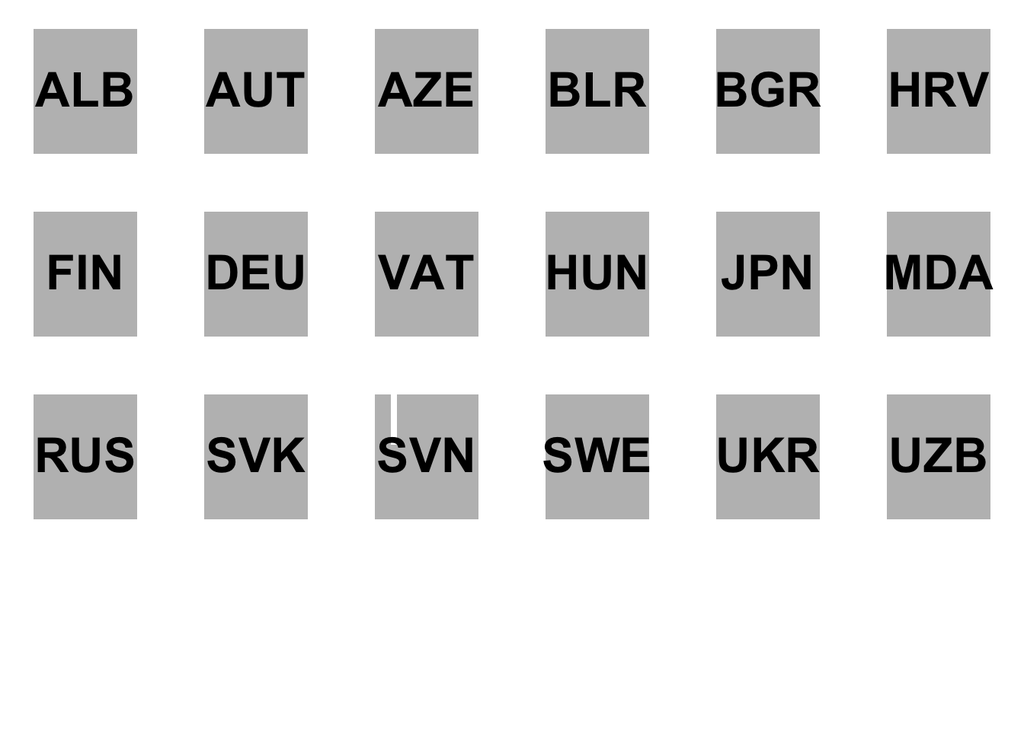

```r
# select all NA cells and assign 0 to them
matleave[is.na(matleave)] <- 0

# filter rows by condition
m5 <- matleave[matleave$'matleave_13' == 5, ]

# filter rows by condition
m55<- m5[m5$'matleave_95' == 5,]

# plot
par(mfrow=c(4,6), mai= c(0.2, 0.2, 0.2, 0.2))
for (i in c(1:nrow(m55))){
    barplot(unlist(m55[i,-1]),
            border=NA, space=0,xaxt="n", yaxt="n", ylim = c(0,5))
    title(m55[i,1], line = -4, cex.main=3)
}
```

# 4 學習者版本

[output not shown]

[output not shown]

```r
dim(ldata)
```

```
## [1] 197 156
```

```r
# Show names of variables (vectors, columns) by names()
names(ldata)
```

```
##   [1] "country"           "iso2"              "iso3"
##   [4] "region"            "wb_econ"           "matleave_95"
##   [7] "matleave_96"       "matleave_97"       "matleave_98"
##  [10] "matleave_99"       "matleave_00"       "matleave_01"
##  [13] "matleave_02"       "matleave_03"       "matleave_04"
##  [16] "matleave_05"       "matleave_06"       "matleave_07"
##  [19] "matleave_08"       "matleave_09"       "matleave_10"
##  [22] "matleave_11"       "matleave_12"       "matleave_13"
##  [25] "matleave_wrr_95"   "matleave_wrr_96"   "matleave_wrr_97"
##  [28] "matleave_wrr_98"   "matleave_wrr_99"   "matleave_wrr_00"
##  [31] "matleave_wrr_01"   "matleave_wrr_02"   "matleave_wrr_03"
##  [34] "matleave_wrr_04"   "matleave_wrr_05"   "matleave_wrr_06"
##  [37] "matleave_wrr_07"   "matleave_wrr_08"   "matleave_wrr_09"
##  [40] "matleave_wrr_10"   "matleave_wrr_11"   "matleave_wrr_12"
##  [43] "matleave_wrr_13"   "bf_dur_95"         "bf_dur_96"
```

[output cut: 37 more lines]

## 4.2 選擇所需的變項

```r
matleave <- ldata[ , c(3, 6:24)]
class(matleave)
```

```
## [1] "tbl_df"     "tbl"        "data.frame"
```

```r
dim(matleave)
```

```
## [1] 197  20
```

```r
str(matleave)
```

```
## Classes 'tbl_df', 'tbl' and 'data.frame':    197 obs. of  20 variables:
##  $ iso3       : chr  "AFG" "ALB" "DZA" "AND" ...
##  $ matleave_95: num  2 5 3 2 2 2 2 3 1 5 ...
##  $ matleave_96: num  2 5 3 2 2 2 2 3 1 5 ...
##  $ matleave_97: num  2 5 3 2 2 2 2 3 1 5 ...
##  $ matleave_98: num  2 5 3 2 2 2 2 3 1 5 ...
##  $ matleave_99: num  2 5 3 2 2 2 2 3 1 5 ...
##  $ matleave_00: num  2 5 3 3 2 2 2 3 1 5 ...
##  $ matleave_01: num  2 5 3 3 2 2 2 3 1 5 ...
##  $ matleave_02: num  2 5 3 3 2 2 2 3 1 5 ...
##  $ matleave_03: num  2 5 3 3 2 2 2 3 1 5 ...
##  $ matleave_04: num  2 5 3 3 2 2 2 5 1 5 ...
##  $ matleave_05: num  2 5 3 3 2 2 2 5 1 5 ...
##  $ matleave_06: num  2 5 3 3 2 2 2 5 1 5 ...
##  $ matleave_07: num  2 5 3 3 2 2 2 5 1 5 ...
##  $ matleave_08: num  2 5 3 3 2 2 2 5 1 5 ...
##  $ matleave_09: num  2 5 3 3 2 2 2 5 1 5 ...
##  $ matleave_10: num  2 5 3 3 2 2 2 5 NA 5 ...
##  $ matleave_11: num  2 5 3 3 2 2 2 5 3 5 ...
##  $ matleave_12: num  2 5 3 3 2 2 2 5 3 5 ...
##  $ matleave_13: num  2 5 3 3 2 2 2 5 3 5 ...
```

## 4.3 取代NA

- `NA: Not Available`
- `v[is.na(v)]` will select all NA cells
- 以0取代NA的資料格。避免繪圖產生錯誤
- `sum(is.na(matleave))`的目的是檢測還有沒有NA值。如果有的話`is.na()`就會是`TRUE`，那麼加總後，如果不是0，那就代表還有NA。

```r
matleave[is.na(matleave)] <- 0

# checks if there are still NA cells.
anyNA(matleave)
```

```
## [1] FALSE
```

```r
sum(is.na(matleave))
```

```
## [1] 0
```

## 4.4 繪圖

- Plotting the second rows and all columns except 1st column
- **Question** 為何要`unlist()`？請試著執行`barplot(matleave[2, -1])`這個沒有`unlist()`的版本，看看會有什麼錯誤訊息。資料結構有何差異呢？
- 嘗試用`class()`或`str()`嘗試觀察沒有`unlist()`版本的資料，看看資料型態和有`unlist()`的會有何不同？

```r
barplot(unlist(matleave[2, -1]))

# Take a look at the data type of matleave[2, ]
class(matleave[2, -1])
```

[output not shown]

```
## [1] "tbl_df"     "tbl"        "data.frame"
```

```r
# Using unlist() to convert a single row dataframe to a vector
unlist(matleave[2, -1])
```

```
## matleave_95 matleave_96 matleave_97 matleave_98 matleave_99 matleave_00
##           5           5           5           5           5           5
## matleave_01 matleave_02 matleave_03 matleave_04 matleave_05 matleave_06
##           5           5           5           5           5           5
## matleave_07 matleave_08 matleave_09 matleave_10 matleave_11 matleave_12
##           5           5           5           5           5           5
## matleave_13
##           5
```

```r
class(unlist(matleave[2, -1]))
```

```
## [1] "numeric"
```

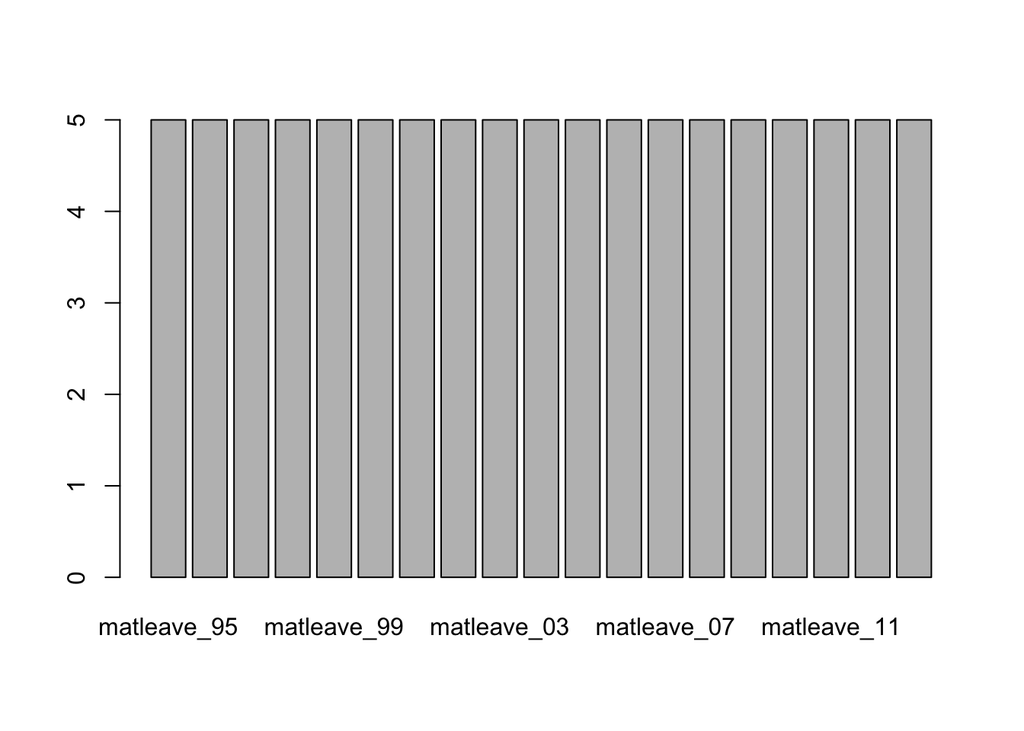

```r
# Add more arguments
barplot(unlist(matleave[2, -1]))
```

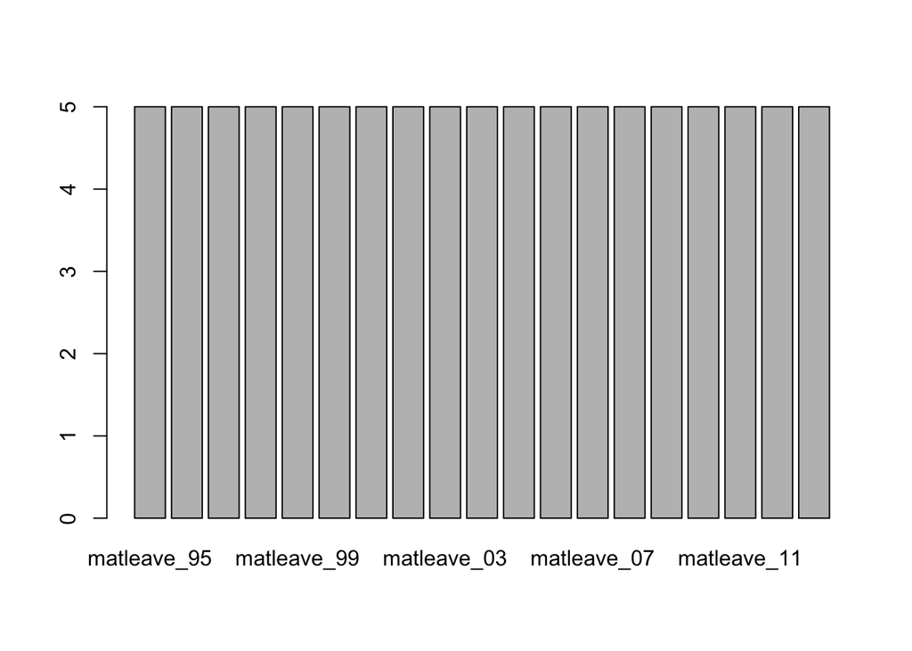

```r
barplot(unlist(matleave[2, -1]), ylim=c(0, 5))
```

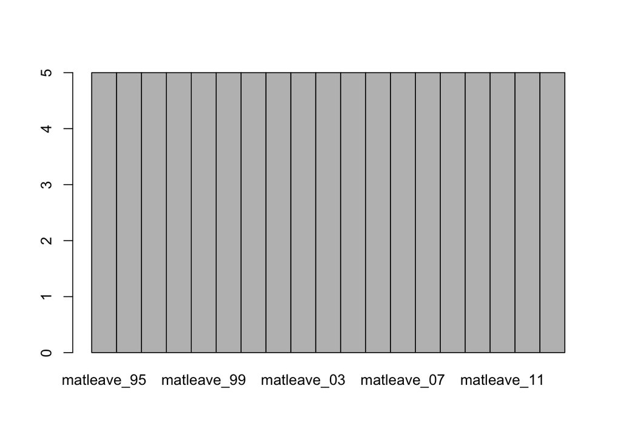

```r
barplot(unlist(matleave[2, -1]), ylim=c(0, 5), space=0)
```

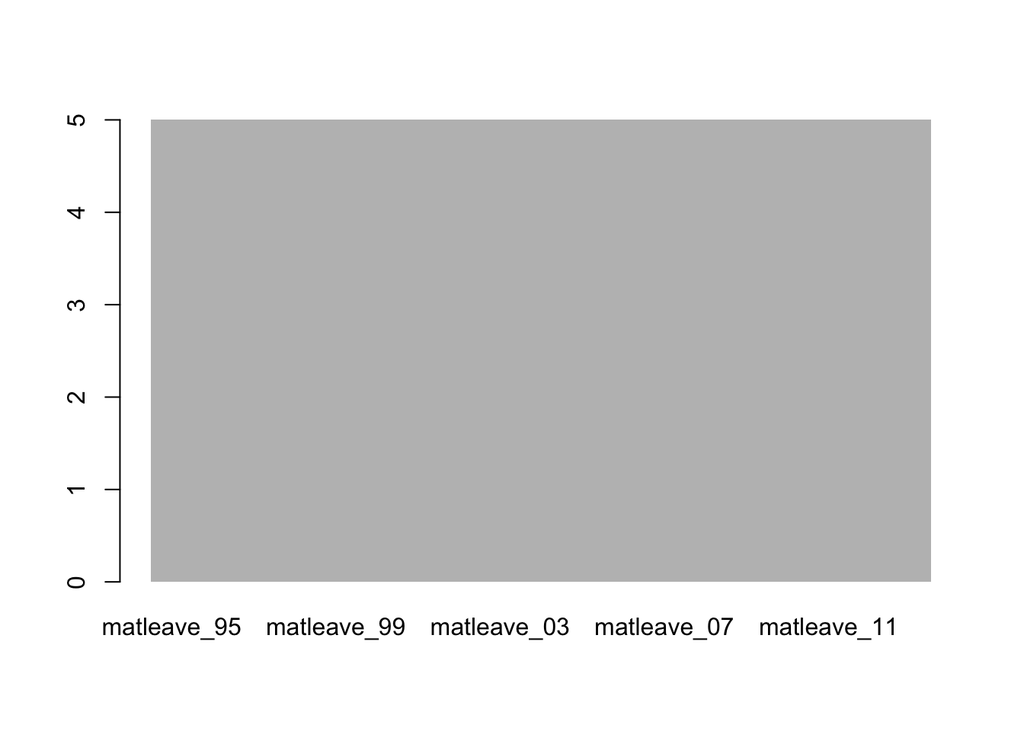

```r
barplot(unlist(matleave[2, -1]), ylim=c(0, 5), space=0, border=NA)
```

```r
barplot(unlist(matleave[2, -1]), ylim=c(0, 5), space=0, border=NA, xaxt="n", yaxt="n")
```

[output not shown]

### 4.4.1 在data.frame中選擇資料

```r
# View(matleave[1]) # select the 1st variable
# View(matleave[ ,1]) # select the 1st column
# View(matleave[1, ]) # select the 1st row

class(matleave[1])      # "tbl_df"     "tbl"        "data.frame"
```

```
## [1] "tbl_df"     "tbl"        "data.frame"
```

```r
class(matleave[ ,1])    # "tbl_df"     "tbl"        "data.frame"
```

```
## [1] "tbl_df"     "tbl"        "data.frame"
```

```r
class(matleave[1, ])    # "tbl_df"     "tbl"        "data.frame"
```

```
## [1] "tbl_df"     "tbl"        "data.frame"
```

```r
class(matleave$iso3)    # character (vector)
```

```
## [1] "character"
```

## 4.5 for-loop

- 底下可以看見每一行非常相似且一致的特徵，僅有`matleave`內的索引由1被列出至6。因此，最好的方法是用迴圈（for-loop）的方式將相同的程式碼，從1~6之間做六次。

```r
barplot(unlist(matleave[1, -1]), ylim=c(0, 5), space=0, border=NA, xaxt="n", yaxt="n")
```

[output not shown]

```r
barplot(unlist(matleave[2, -1]), ylim=c(0, 5), space=0, border=NA, xaxt="n", yaxt="n")
```

[output not shown]

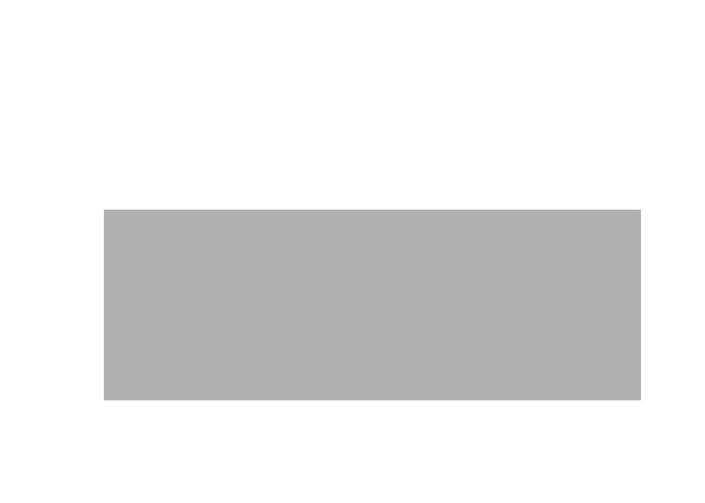

```r
barplot(unlist(matleave[3, -1]), ylim=c(0, 5), space=0, border=NA, xaxt="n", yaxt="n")
```

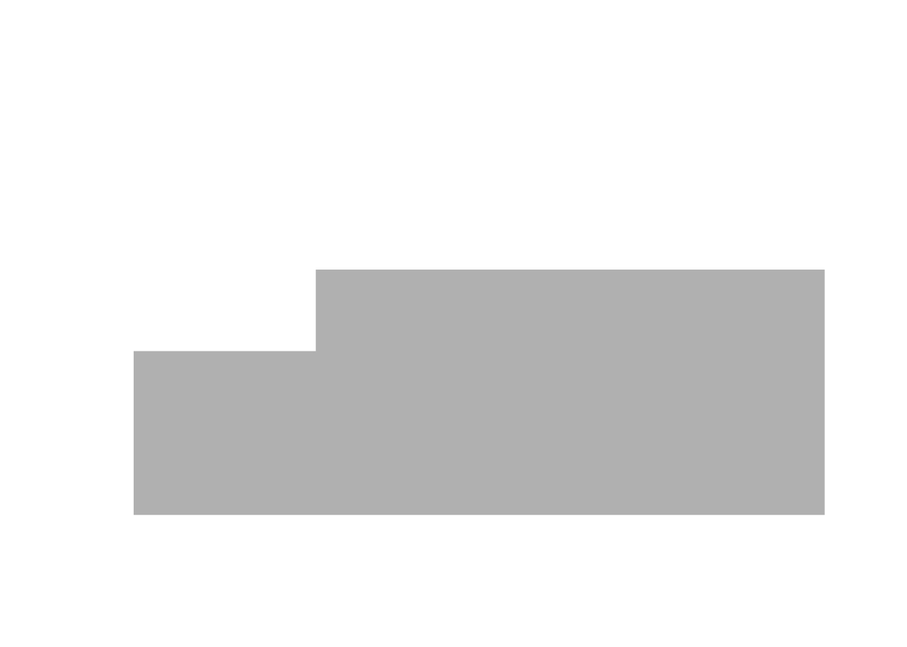

```r
barplot(unlist(matleave[4, -1]), ylim=c(0, 5), space=0, border=NA, xaxt="n", yaxt="n")
```

```r
barplot(unlist(matleave[5, -1]), ylim=c(0, 5), space=0, border=NA, xaxt="n", yaxt="n")
```

[output not shown]

```r
barplot(unlist(matleave[6, -1]), ylim=c(0, 5), space=0, border=NA, xaxt="n", yaxt="n")
```

[output not shown]

- 使用for-loop的版本

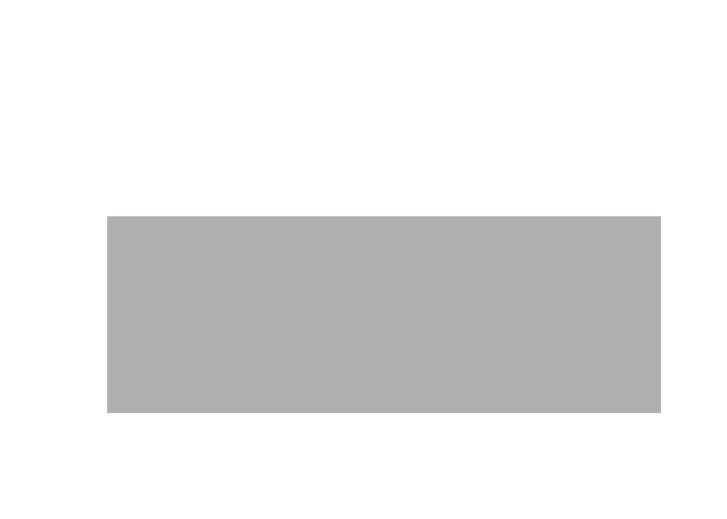

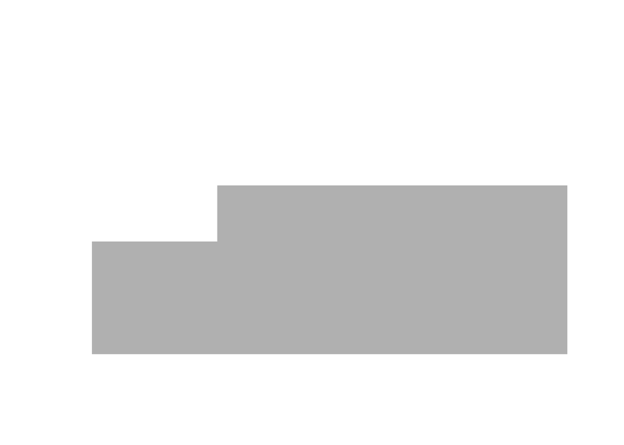

```r
for(i in 1:6){
  barplot(unlist(matleave[i, -1]), ylim=c(0, 5), space=0, border=NA, xaxt="n", yaxt="n")
}
```

# 5 繪製子圖

- Check `?par` to get paremeters of plotting
- `**mai**`: A numerical vector of the form c(bottom, left, top, right) which gives the margin size specified in inches.
- `**mfcol, mfrow**`:A vector of the form c(nr, nc). Subsequent figures will be drawn in an nr-by-nc array on the device by columns (mfcol), or rows (mfrow), respectively.

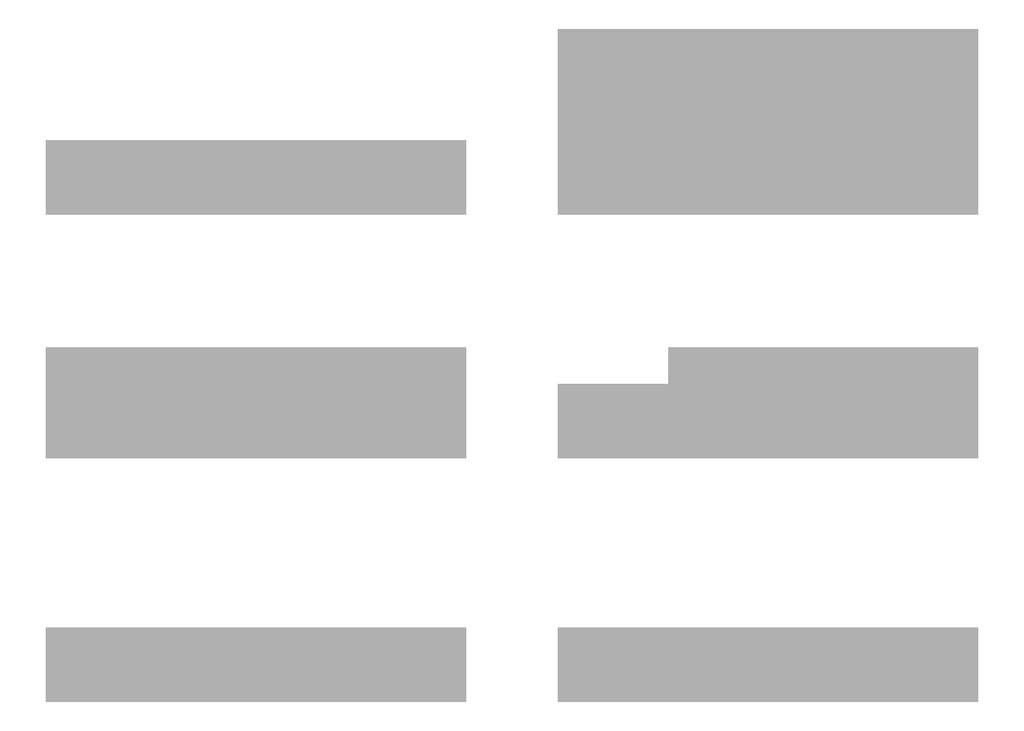

```r
par(mfrow=c(3,2), mai= c(0.2, 0.2, 0.2, 0.2))
for(i in 1:6){
  barplot(unlist(matleave[i, -1]), ylim=c(0, 5), space=0, border=NA, xaxt="n", yaxt="n")
}
```

## 5.1 Practice

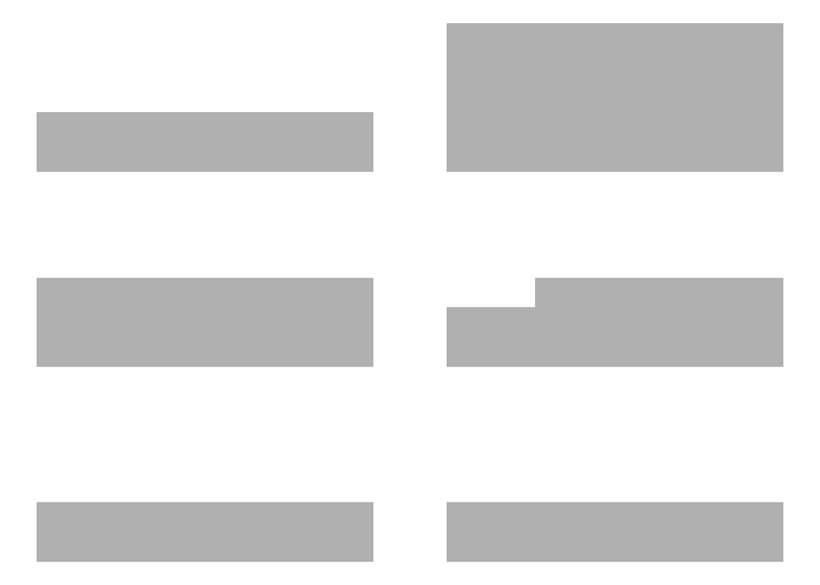

```r
# plot more rows to see what happens
par(mfrow=c(3,2), mai= c(0.2, 0.2, 0.2, 0.2))
for(i in 1:10){
    barplot(unlist(matleave[i, -1]), ylim=c(0, 5), space=0, border=NA, xaxt="n", yaxt="n")
}
```

[figure not shown]

```r
# plot all subplots in a figure
```

# 6 Filter data by the last year value

```r
m5 <- matleave[matleave$'matleave_13'==5, ]
nrow(m5)
```

```
## [1] 34
```

```r
# matleave$'matleave_13'
# matleave$'matleave_13'==5
# length(matleave$'matleave_13'==5)
```

# 7 Filter data by the first year value

```r
# filter rows whose 'matleave_95' is 5
m55<- m5[m5$'matleave_95'==5,]

# filter rows whose 'matleave_95' is not 5
m05<- m5[m5$'matleave_95'!=5,]
```

# 8 Plot m55

```r
nrow(m55)
```

```
## [1] 18
```

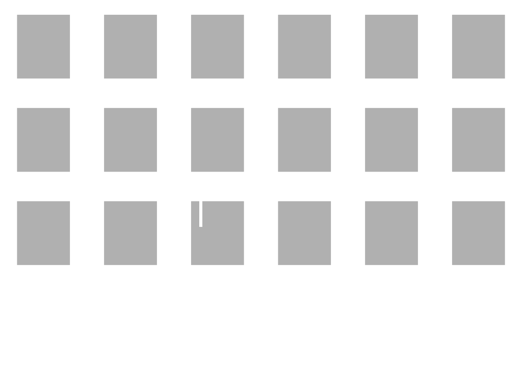

```r
par(mfrow=c(4, 6), mai= c(0.2, 0.2, 0.2, 0.2))
for (i in 1:nrow(m55)){
  barplot(unlist(m55[i, -1]), border=NA, space=0, xaxt="n", yaxt="n", ylim = c(0,5))
}


# How do you add title for each subplot?
par(mfrow=c(4,6), mai= c(0.2, 0.2, 0.2, 0.2))
```

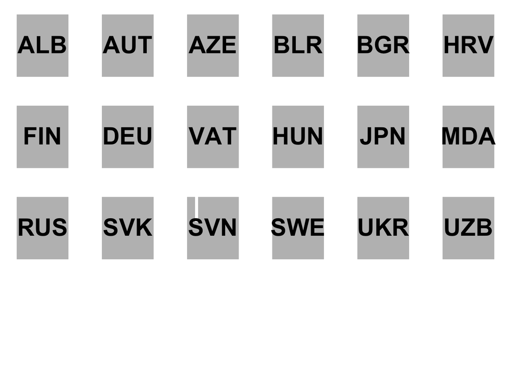

```r
for (i in 1:nrow(m55)){
    barplot(unlist(m55[i, -1]), border=NA, space=0,xaxt="n", yaxt="n", ylim = c(0,5))
    title(m55[i,1], line = -4, cex.main=3)
}
```

# 9 Practice

```r
# plotting matleave_95 != 5 but matleve_13 == 5

# plotting for matleave_13 == 4

# Select, and filter data in dplyr form
```

# 10 by dplyr

```r
library(dplyr)
m55 <- ldata %>%
    select(iso3, contains("matleave"), -contains("wrr")) %>%
    mutate_if(is.numeric, function(x){ifelse(is.na(x), 0, x)}) %>%
    filter(matleave_13==5, matleave_95==5)
```

## 10.1 More: gather() to long-form

```r
library(tidyr)
# Gather 2:20 column to a new variable "year"
# Name level data as "degree"
long_form <- gather(matleave, "year", "degree", 2:20)
```

# 11 Drawing worldmap

```r
# install.packages("rworldmap")
library(rworldmap)# drawing worldmap

# select cols
mdata <- ldata[,c(3, 6:24)]

# join your data with the world map data
myMap <- joinCountryData2Map(mdata, joinCode = "ISO3", nameJoinColumn = "iso3")
```

```
## 196 codes from your data successfully matched countries in the map
## 1 codes from your data failed to match with a country code in the map
## 47 codes from the map weren't represented in your data
```

```r
# 196 codes from your data successfully matched countries in the map
# 1 codes from your data failed to match with a country code in the map
# 47 codes from the map weren't represented in your data

myMap$matleave_13
```

```
##   [1]  2  2  5  2  2  5 NA NA  3  5  5  2  4  3  3  3  5  2  5  5  3  2  3
##  [24]  3  2  2  3  4  3  4  3  3  3  3  3  3  3  5 NA  3  5  5  3  5  2  3
##  [47]  2  2  2  3  5  2  5  2 NA  4  3  4  3  2  3  4  2  2  4 NA  2  2  2
##  [70]  5  2  5  2  2  4  4  2  4  3  4  2  2  5  3  2  3  2  5 NA  2  2  2
##  [93]  2  3  2  2  5  4  5  3  5  3  2  4  3  2  5  5  2  3  2  2  2 NA  3
## [116]  2  2  3  4  2  3  2  2  3  2  2  1  5 NA  2  4  2  2  5  5  2 NA  2
## [139]  2  2  3  2  2  2  3  5  1  5  5  5  2  3  3  3  2  5  3  2  3  2  3
## [162] NA  2  2  5  2  1  5  4  4  2 NA  2  3  3  3 NA NA NA  3 NA NA  2  2
## [185] NA NA  2  2  3  2 NA NA  2 NA  1 NA NA  2 NA NA NA NA NA NA NA NA  2
## [208]  2  2  3 NA NA  3  2  1  3 NA NA  2 NA  1  1 NA  1 NA  3 NA NA  5 NA
## [231]  2 NA  3 NA  1  5  2 NA NA NA  2  2 NA
```

```r
# Draw world maps
dev.off()
```

```r
mapCountryData(myMap
               , nameColumnToPlot="matleave_13"
               , catMethod = "categorical"
)


# self-defined colors
colors <- c("#FF8000", "#A9D0F5", "#58ACFA", "#0080FF", "#084B8A")
mapCountryData(myMap
               , nameColumnToPlot="matleave_13"
               , catMethod = "categorical"
               , colourPalette = colors
               , addLegend="FALSE"
)
```

[output not shown]

# 12 Practice

- Drawing map for the first year
- Remember to setting `par()` for plotting as subplots

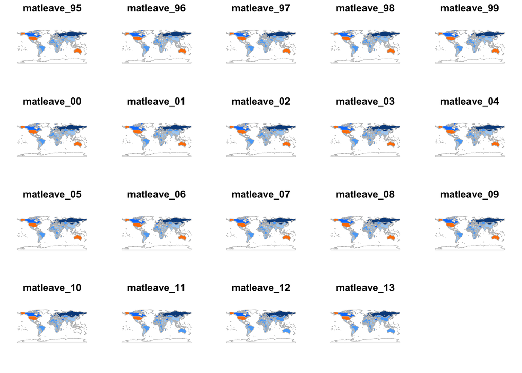

```r
par(mfrow=c(4,5), mai= c(0.2, 0.2, 0.2, 0.2))
for(i in 51:69){
    mapCountryData(myMap
                   , nameColumnToPlot=names(myMap)[i]
                   , catMethod = "categorical"
                   , colourPalette = colors
                   , addLegend="FALSE"
                   )
}
```

# 13 Summarize data

```r
# select 1 to 24 vectors
tdata <- ldata[ ,1:24]
names(tdata)
```

```
##  [1] "country"     "iso2"        "iso3"        "region"      "wb_econ"
##  [6] "matleave_95" "matleave_96" "matleave_97" "matleave_98" "matleave_99"
## [11] "matleave_00" "matleave_01" "matleave_02" "matleave_03" "matleave_04"
## [16] "matleave_05" "matleave_06" "matleave_07" "matleave_08" "matleave_09"
## [21] "matleave_10" "matleave_11" "matleave_12" "matleave_13"
```

```r
# deal with NAs
tdata[is.na(tdata)] <- 0

# create contigency table by region for matleave_13: data count by length()
num <- tapply(ldata$matleave_13, ldata$region, length)

# tapply() using mean(), sum(), and sd
total <- tapply(ldata$matleave_13, ldata$region, mean)
average <- tapply(ldata$matleave_13, ldata$region, sum)
sd <- tapply(ldata$matleave_13, ldata$region, sd)

# create data frame for about variables
res <- data.frame(num, average, total, sd)
# View(res)
```

# 14 Grouping data: merge rows by category

```r
byregion <- aggregate(tdata[,6:24], by=list(tdata$region), mean)
# View(byregion)
byregion.sd <- aggregate(tdata[,6:24], by=list(tdata$region), sd)
?aggregate

head(byregion)
```

```
##                      Group.1 matleave_95 matleave_96 matleave_97
## 1                   Americas    2.171429    2.171429    2.171429
## 2        East Asia & Pacific    1.750000    1.750000    1.750000
## 3      Europe & Central Asia    3.272727    3.272727    3.400000
## 4 Middle East & North Africa    2.000000    2.000000    2.000000
## 5                 South Asia    1.625000    1.625000    1.625000
## 6         Sub-Saharan Africa    2.208333    2.208333    2.229167
##   matleave_98 matleave_99 matleave_00 matleave_01 matleave_02 matleave_03
## 1    2.171429    2.142857    2.200000     2.20000    2.200000    2.257143
## 2    1.750000    1.750000    1.750000     1.84375    1.937500    2.000000
## 3    3.381818    3.436364    3.581818     3.60000    3.654545    3.872727
## 4    2.000000    2.000000    2.000000     2.00000    2.157895    2.157895
## 5    1.625000    1.625000    1.625000     1.62500    1.625000    1.625000
## 6    2.229167    2.187500    2.270833     2.31250    2.333333    2.333333
##   matleave_04 matleave_05 matleave_06 matleave_07 matleave_08 matleave_09
## 1    2.257143    2.257143    2.257143    2.257143    2.257143    2.257143
## 2    2.000000    2.031250    2.031250    2.031250    2.031250    2.062500
## 3    3.963636    4.018182    4.109091    4.127273    4.200000    4.218182
## 4    2.263158    2.263158    2.263158    2.263158    2.315789    2.368421
## 5    1.625000    1.625000    1.750000    1.625000    1.875000    2.125000
## 6    2.333333    2.354167    2.395833    2.395833    2.395833    2.395833
##   matleave_10 matleave_11 matleave_12 matleave_13
## 1    2.257143    2.314286    2.371429    2.371429
## 2    2.031250    2.156250    2.250000    2.281250
## 3    4.254545    4.254545    4.272727    4.309091
## 4    2.421053    2.421053    2.421053    2.421053
## 5    2.125000    2.125000    2.125000    2.125000
## 6    2.458333    2.500000    2.500000    2.500000
```

# 15 Plotting results

```r
# Line ploting the 1st row
dev.off()
```

```r
plot(unlist(byregion[1,]), type="o")
# Line ploting the 2nd~6th rows
plot(unlist(byregion[2,]), type="o")
plot(unlist(byregion[3,]), type="o")
plot(unlist(byregion[4,]), type="o")
plot(unlist(byregion[5,]), type="o")
plot(unlist(byregion[6,]), type="o")
# Using for-loop and par() to plot all graph
par(mfrow=c(3,2), mai= rep(0.3, 4))
for (i in 1:6){
    plot(unlist(byregion[i,-1]), type="o", ylim=c(0, 5))
    title(byregion[i,1])
}
```

[output not shown]

## 15.1 The fittest version to compute staySame

```r
# staySame version
# staySame <- apply(m5[,2:20], 1, function(x) length(unique(x[!is.na(x)])))
# m55 <- m5[staySame, ]
# m50 <- m5[!staySame, ]
```

# 16 by dplyr

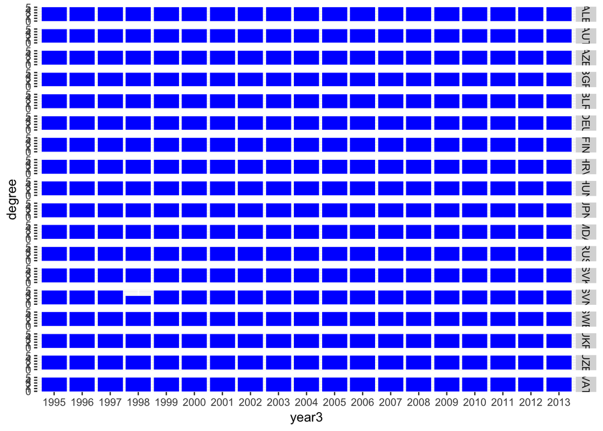

```r
library(dplyr)
library(tidyr)
library(ggplot2)

long_form <- gather(matleave, "year", "degree", 2:20)

matleave <- ldata %>%
    select(iso3, contains("matleave"), -contains("wrr")) %>%
    filter(matleave_13==5, matleave_95==5) %>%
    gather("year", "degree", 2:20) %>%
    replace_na(list(degree=0)) %>%
    mutate(year2=as.POSIXct(strptime(year, "matleave_%y"))) %>%
    mutate(year3 = strftime(year2, "%Y"))

matleave %>%
    ggplot() +
    aes(year3, degree) +
    facet_grid(iso3~.) +
    geom_bar(stat = "identity", fill = "blue")
```